### 结论二 Alcohol影响葡萄酒质量

根据双变量分析结论，alcohol 跟质量是正相关的

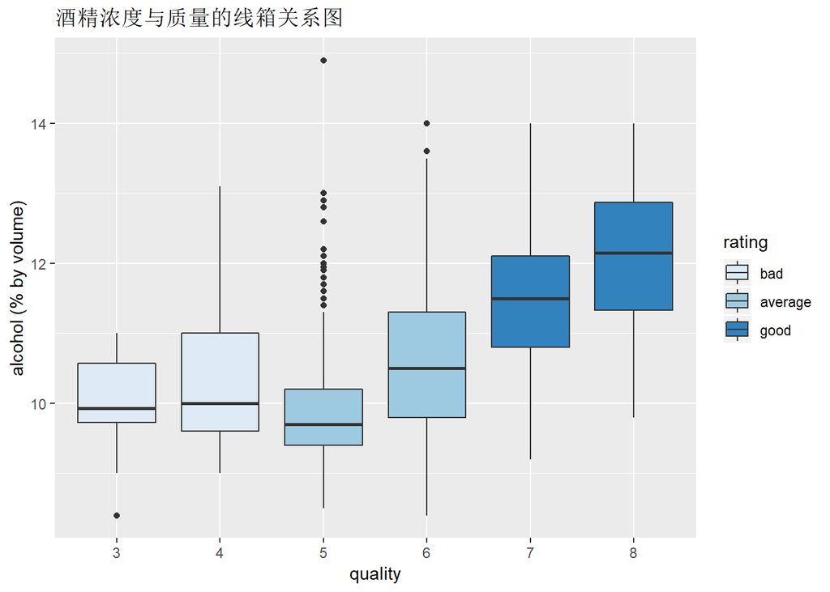

```r
ggplot(data = pf, aes( x = quality, y = alcohol, fill = rating)) +
  geom_boxplot() +
  scale_fill_brewer(palette = "Blues")+
  xlab('quality') +
  ylab('alcohol (% by volume)')+
  ggtitle('酒精浓度与质量的线箱关系图')
```

- 一般来说，高质量葡萄酒含有较高的酒精含量，但是单独看酒精对质量的影响并不是那么强；

### 结论三 究竟什么影响葡萄酒质量

将多变量分析中的average评级去更好的观察酒的质量。

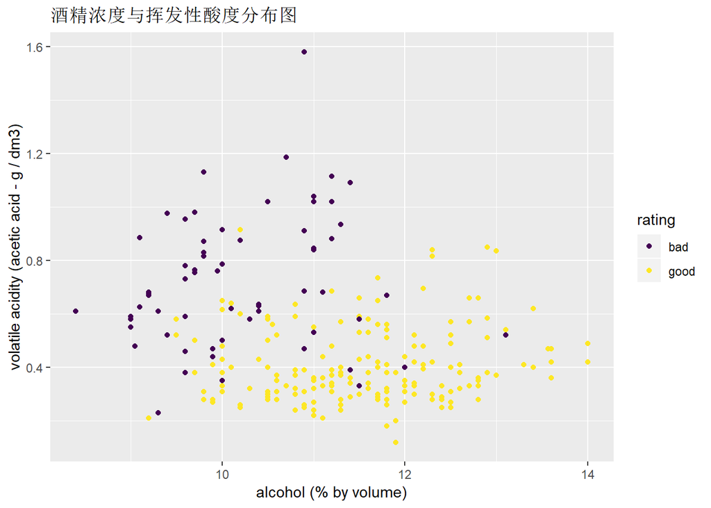

```r
ggplot(data = subset(pf, rating != 'average'),
       aes(x = alcohol, y = volatile.acidity, color = rating)) +
  geom_point() +
  xlab('alcohol (% by volume)') +
  ylab('volatile acidity (acetic acid - g / dm³)')+
  ggtitle('酒精浓度与挥发性酸度分布图')
```

图中去掉了中级葡萄酒的影响，也没有采用以上通用的渐变色表达，因为渐变色不明显，看不清楚，现在可以更明显的看到： 高酒精含量alcohol 和 低挥发性酸度volatile acid 组合起来，可以产生更优质的葡萄酒；

## 反思

分析过程中成功的发现部分： 单变量分析时，对各变量都进行了探索，ph，密度，固定酸度，挥发性酸度，硫酸盐，酒精。 后来双变量分析时越来越清晰， 最后多变量分析时，明确了高酒精含量 和 低挥发性酸度，对葡萄酒质量影响非常大；

分析过程中遇到的难点： 在单变量分析时，以为密度会对葡萄酒质量有较大的关联，但是通过双变量分析，发现并没有神马关系， 考虑问题还是要多一个维度，会更加的客观，发现真相。

未来如何进一步丰富分析内容和提高报告质量： 可以收集白酒和其他酒类的相关影响因素数据，看看是否影响酒类的因素都是一样的，这样对酒类的了解就更加全面了，也有利于指导酒类生产；